# Optimal Treatment Analysis

## Outcome Variable

**Outcome Variable:** whz

## Predictor Variables

**Intervention Variable:** exclfeed36

**Adjustment Set:**

- arm
- sex
- brthmon
- W_mage
- meducyrs
- feducyrs
- hhwealth_quart
- hfoodsec
- W_mhtcm
- W_mwtkg
- W_mbmi
- vagbrth
- W_gagebrth
- W_birthwt
- W_birthlen
- W_nrooms
- W_nchldlt5
- month
- W_parity
- impfloor
- impsan
- safeh20
- delta_W_mage
- delta_meducyrs
- delta_feducyrs
- delta_hhwealth_quart
- delta_hfoodsec
- delta_W_mhtcm
- delta_W_mwtkg
- delta_W_mbmi
- delta_vagbrth
- delta_W_gagebrth
- delta_W_birthwt
- delta_W_birthlen
- delta_W_nrooms
- delta_W_nchldlt5
- delta_month
- delta_W_parity
- delta_impfloor
- delta_impsan
- delta_safeh20

## Stratifying Variables

The analysis was stratified on these variable(s):

- agecat
- studyid
- country

## Data Summary

| agecat | studyid | country | exclfeed36 | n_cell | n |
| --- | --- | --- | --- | --- | --- |
| Birth | ki0047075b-MAL-ED | BANGLADESH | 1 | 31 | 208 |
| Birth | ki0047075b-MAL-ED | BANGLADESH | 0 | 177 | 208 |
| Birth | ki0047075b-MAL-ED | BRAZIL | 1 | 4 | 62 |
| Birth | ki0047075b-MAL-ED | BRAZIL | 0 | 58 | 62 |
| Birth | ki0047075b-MAL-ED | INDIA | 1 | 1 | 40 |
| Birth | ki0047075b-MAL-ED | INDIA | 0 | 39 | 40 |
| Birth | ki0047075b-MAL-ED | NEPAL | 1 | 0 | 25 |
| Birth | ki0047075b-MAL-ED | NEPAL | 0 | 25 | 25 |
| Birth | ki0047075b-MAL-ED | PERU | 1 | 5 | 218 |
| Birth | ki0047075b-MAL-ED | PERU | 0 | 213 | 218 |
| Birth | ki0047075b-MAL-ED | SOUTH AFRICA | 1 | 1 | 104 |
| Birth | ki0047075b-MAL-ED | SOUTH AFRICA | 0 | 103 | 104 |
| Birth | ki0047075b-MAL-ED | TANZANIA, UNITED REPUBLIC OF | 1 | 0 | 111 |
| Birth | ki0047075b-MAL-ED | TANZANIA, UNITED REPUBLIC OF | 0 | 111 | 111 |
| Birth | ki1000108-CMC-V-BCS-2002 | INDIA | 1 | 3 | 3 |
| Birth | ki1000108-CMC-V-BCS-2002 | INDIA | 0 | 0 | 3 |
| Birth | ki1000108-IRC | INDIA | 1 | 0 | 3 |
| Birth | ki1000108-IRC | INDIA | 0 | 3 | 3 |
| Birth | ki1000109-EE | PAKISTAN | 1 | 2 | 6 |
| Birth | ki1000109-EE | PAKISTAN | 0 | 4 | 6 |
| Birth | ki1017093b-PROVIDE | BANGLADESH | 1 | 115 | 483 |
| Birth | ki1017093b-PROVIDE | BANGLADESH | 0 | 368 | 483 |
| Birth | ki1101329-Keneba | GAMBIA | 1 | 343 | 1192 |
| Birth | ki1101329-Keneba | GAMBIA | 0 | 849 | 1192 |
| Birth | ki1113344-GMS-Nepal | NEPAL | 1 | 396 | 491 |
| Birth | ki1113344-GMS-Nepal | NEPAL | 0 | 95 | 491 |
| Birth | kiGH5241-JiVitA-3 | BANGLADESH | 1 | 6736 | 8619 |
| Birth | kiGH5241-JiVitA-3 | BANGLADESH | 0 | 1883 | 8619 |
| Birth | kiGH5241-JiVitA-4 | BANGLADESH | 1 | 1711 | 2128 |
| Birth | kiGH5241-JiVitA-4 | BANGLADESH | 0 | 417 | 2128 |

[output cut: 66 more lines]

The following strata were considered:

- agecat: 24 months, studyid: ki0047075b-MAL-ED, country: BANGLADESH
- agecat: 24 months, studyid: ki0047075b-MAL-ED, country: BRAZIL
- agecat: 24 months, studyid: ki0047075b-MAL-ED, country: INDIA
- agecat: 24 months, studyid: ki0047075b-MAL-ED, country: NEPAL
- agecat: 24 months, studyid: ki0047075b-MAL-ED, country: PERU
- agecat: 24 months, studyid: ki0047075b-MAL-ED, country: SOUTH AFRICA
- agecat: 24 months, studyid: ki0047075b-MAL-ED, country: TANZANIA, UNITED REPUBLIC OF
- agecat: 24 months, studyid: ki1000108-CMC-V-BCS-2002, country: INDIA
- agecat: 24 months, studyid: ki1000108-IRC, country: INDIA
- agecat: 24 months, studyid: ki1000109-EE, country: PAKISTAN
- agecat: 24 months, studyid: ki1017093b-PROVIDE, country: BANGLADESH
- agecat: 24 months, studyid: ki1101329-Keneba, country: GAMBIA
- agecat: 24 months, studyid: ki1113344-GMS-Nepal, country: NEPAL
- agecat: 24 months, studyid: ki1148112-LCNI-5, country: MALAWI
- agecat: 24 months, studyid: kiGH5241-JiVitA-3, country: BANGLADESH
- agecat: 24 months, studyid: kiGH5241-JiVitA-4, country: BANGLADESH
- agecat: 6 months, studyid: ki0047075b-MAL-ED, country: BANGLADESH
- agecat: 6 months, studyid: ki0047075b-MAL-ED, country: BRAZIL
- agecat: 6 months, studyid: ki0047075b-MAL-ED, country: INDIA
- agecat: 6 months, studyid: ki0047075b-MAL-ED, country: NEPAL
- agecat: 6 months, studyid: ki0047075b-MAL-ED, country: PERU
- agecat: 6 months, studyid: ki0047075b-MAL-ED, country: SOUTH AFRICA
- agecat: 6 months, studyid: ki0047075b-MAL-ED, country: TANZANIA, UNITED REPUBLIC OF
- agecat: 6 months, studyid: ki1000108-CMC-V-BCS-2002, country: INDIA
- agecat: 6 months, studyid: ki1000108-IRC, country: INDIA
- agecat: 6 months, studyid: ki1000109-EE, country: PAKISTAN
- agecat: 6 months, studyid: ki1000304b-SAS-FoodSuppl, country: INDIA
- agecat: 6 months, studyid: ki1017093b-PROVIDE, country: BANGLADESH
- agecat: 6 months, studyid: ki1101329-Keneba, country: GAMBIA
- agecat: 6 months, studyid: ki1113344-GMS-Nepal, country: NEPAL
- agecat: 6 months, studyid: ki1148112-LCNI-5, country: MALAWI
- agecat: 6 months, studyid: kiGH5241-JiVitA-3, country: BANGLADESH
- agecat: 6 months, studyid: kiGH5241-JiVitA-4, country: BANGLADESH
- agecat: Birth, studyid: ki0047075b-MAL-ED, country: BANGLADESH
- agecat: Birth, studyid: ki0047075b-MAL-ED, country: BRAZIL
- agecat: Birth, studyid: ki0047075b-MAL-ED, country: INDIA
- agecat: Birth, studyid: ki0047075b-MAL-ED, country: NEPAL
- agecat: Birth, studyid: ki0047075b-MAL-ED, country: PERU
- agecat: Birth, studyid: ki0047075b-MAL-ED, country: SOUTH AFRICA
- agecat: Birth, studyid: ki0047075b-MAL-ED, country: TANZANIA, UNITED REPUBLIC OF
- agecat: Birth, studyid: ki1000108-CMC-V-BCS-2002, country: INDIA
- agecat: Birth, studyid: ki1000108-IRC, country: INDIA
- agecat: Birth, studyid: ki1000109-EE, country: PAKISTAN
- agecat: Birth, studyid: ki1017093b-PROVIDE, country: BANGLADESH
- agecat: Birth, studyid: ki1101329-Keneba, country: GAMBIA
- agecat: Birth, studyid: ki1113344-GMS-Nepal, country: NEPAL
- agecat: Birth, studyid: kiGH5241-JiVitA-3, country: BANGLADESH
- agecat: Birth, studyid: kiGH5241-JiVitA-4, country: BANGLADESH

### Dropped Strata

Some strata were dropped due to rare outcomes:

- agecat: Birth, studyid: ki0047075b-MAL-ED, country: BRAZIL
- agecat: Birth, studyid: ki0047075b-MAL-ED, country: INDIA
- agecat: Birth, studyid: ki0047075b-MAL-ED, country: NEPAL
- agecat: Birth, studyid: ki0047075b-MAL-ED, country: SOUTH AFRICA
- agecat: Birth, studyid: ki0047075b-MAL-ED, country: TANZANIA, UNITED REPUBLIC OF
- agecat: Birth, studyid: ki1000108-CMC-V-BCS-2002, country: INDIA
- agecat: Birth, studyid: ki1000108-IRC, country: INDIA
- agecat: Birth, studyid: ki1000109-EE, country: PAKISTAN
- agecat: 6 months, studyid: ki0047075b-MAL-ED, country: NEPAL
- agecat: 6 months, studyid: ki0047075b-MAL-ED, country: SOUTH AFRICA
- agecat: 6 months, studyid: ki0047075b-MAL-ED, country: TANZANIA, UNITED REPUBLIC OF
- agecat: 6 months, studyid: ki1000108-CMC-V-BCS-2002, country: INDIA
- agecat: 6 months, studyid: ki1000108-IRC, country: INDIA
- agecat: 6 months, studyid: ki1000109-EE, country: PAKISTAN
- agecat: 6 months, studyid: ki1000304b-SAS-FoodSuppl, country: INDIA
- agecat: 24 months, studyid: ki0047075b-MAL-ED, country: NEPAL
- agecat: 24 months, studyid: ki0047075b-MAL-ED, country: PERU
- agecat: 24 months, studyid: ki0047075b-MAL-ED, country: SOUTH AFRICA
- agecat: 24 months, studyid: ki0047075b-MAL-ED, country: TANZANIA, UNITED REPUBLIC OF
- agecat: 24 months, studyid: ki1000108-CMC-V-BCS-2002, country: INDIA
- agecat: 24 months, studyid: ki1000108-IRC, country: INDIA
- agecat: 24 months, studyid: ki1000109-EE, country: PAKISTAN

## Methods Detail

We’re interested in the causal parameters $E[Y_a]$ for all values of $a \in \mathcal{A}$. These parameters represent the mean outcome if, possibly contrary to fact, we intervened to set all units to have $A=a$. Under the randomization and positivity assumptions, these are identified by the statistical parameters $\psi_a=E_W[E_{Y|A,W}(Y|A=a,W)]$. In addition, we’re interested in the mean of $Y$, $E[Y]$ under no intervention (the observed mean). We will estimate these parameters by using SuperLearner to fit the relevant likelihood factors – $E_{Y|A,W}(Y|A=a,W)$ and $p(A=a|W)$, and then updating our likelihood fit using a joint TMLE.

For unadjusted analyses ($W=\{\}$), initial likelihoods were estimated using Lrnr_glm to estimate the simple $E(Y|A)$ and Lrnr_mean to estimate $p(A)$. For adjusted analyses, a small library containing Lrnr_glmnet, Lrnr_xgboost, and Lrnr_mean was used.

# Results Detail

## Results Plots

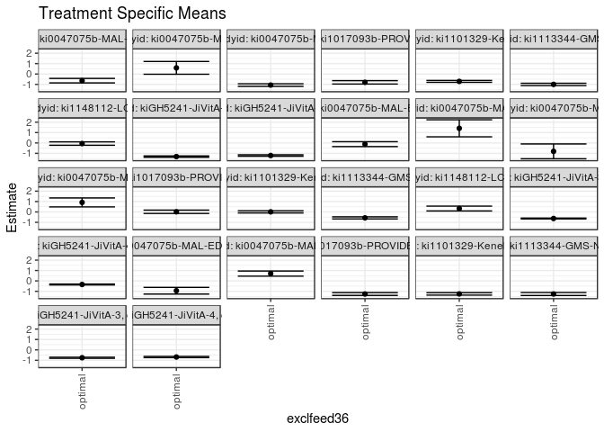

## Results Table

### Parameter: TSM

| agecat | studyid | country | intervention_level | baseline_level | estimate | ci_lower | ci_upper |
| --- | --- | --- | --- | --- | --- | --- | --- |
| Birth | ki0047075b-MAL-ED | BANGLADESH | optimal | observed | -0.9452737 | -1.2668564 | -0.6236909 |
| Birth | ki0047075b-MAL-ED | PERU | optimal | observed | 0.7045999 | 0.4572787 | 0.9519211 |
| Birth | ki1017093b-PROVIDE | BANGLADESH | optimal | observed | -1.2607742 | -1.3932213 | -1.1283271 |
| Birth | ki1101329-Keneba | GAMBIA | optimal | observed | -1.2509745 | -1.3678386 | -1.1341104 |
| Birth | ki1113344-GMS-Nepal | NEPAL | optimal | observed | -1.2597215 | -1.4018072 | -1.1176357 |
| Birth | kiGH5241-JiVitA-3 | BANGLADESH | optimal | observed | -0.7572220 | -0.8099096 | -0.7045343 |
| Birth | kiGH5241-JiVitA-4 | BANGLADESH | optimal | observed | -0.6883235 | -0.7445175 | -0.6321295 |
| 6 months | ki0047075b-MAL-ED | BANGLADESH | optimal | observed | -0.1122656 | -0.3479281 | 0.1233969 |
| 6 months | ki0047075b-MAL-ED | BRAZIL | optimal | observed | 1.4097971 | 0.5892734 | 2.2303209 |
| 6 months | ki0047075b-MAL-ED | INDIA | optimal | observed | -0.8072046 | -1.5203563 | -0.0940529 |
| 6 months | ki0047075b-MAL-ED | PERU | optimal | observed | 0.9147631 | 0.4836389 | 1.3458874 |
| 6 months | ki1017093b-PROVIDE | BANGLADESH | optimal | observed | 0.0144279 | -0.1455765 | 0.1744324 |
| 6 months | ki1101329-Keneba | GAMBIA | optimal | observed | 0.0076953 | -0.0974641 | 0.1128547 |
| 6 months | ki1113344-GMS-Nepal | NEPAL | optimal | observed | -0.5715130 | -0.6715787 | -0.4714473 |
| 6 months | ki1148112-LCNI-5 | MALAWI | optimal | observed | 0.3268064 | 0.0930803 | 0.5605325 |
| 6 months | kiGH5241-JiVitA-3 | BANGLADESH | optimal | observed | -0.6313865 | -0.6709625 | -0.5918106 |
| 6 months | kiGH5241-JiVitA-4 | BANGLADESH | optimal | observed | -0.3439235 | -0.3897447 | -0.2981024 |
| 24 months | ki0047075b-MAL-ED | BANGLADESH | optimal | observed | -0.6423090 | -0.8585262 | -0.4260919 |
| 24 months | ki0047075b-MAL-ED | BRAZIL | optimal | observed | 0.5901087 | -0.0259240 | 1.2061414 |
| 24 months | ki0047075b-MAL-ED | INDIA | optimal | observed | -1.0655418 | -1.1886624 | -0.9424213 |
| 24 months | ki1017093b-PROVIDE | BANGLADESH | optimal | observed | -0.8024047 | -0.9652323 | -0.6395771 |
| 24 months | ki1101329-Keneba | GAMBIA | optimal | observed | -0.7121077 | -0.8053410 | -0.6188743 |
| 24 months | ki1113344-GMS-Nepal | NEPAL | optimal | observed | -1.0026252 | -1.1139454 | -0.8913051 |
| 24 months | ki1148112-LCNI-5 | MALAWI | optimal | observed | -0.0564328 | -0.2198970 | 0.1070314 |
| 24 months | kiGH5241-JiVitA-3 | BANGLADESH | optimal | observed | -1.3104432 | -1.3748815 | -1.2460049 |
| 24 months | kiGH5241-JiVitA-4 | BANGLADESH | optimal | observed | -1.2077539 | -1.2765372 | -1.1389705 |

### Parameter: E(Y)

| agecat | studyid | country | intervention_level | baseline_level | estimate | ci_lower | ci_upper |
| --- | --- | --- | --- | --- | --- | --- | --- |
| Birth | ki0047075b-MAL-ED | BANGLADESH | observed | observed | -0.9480769 | -1.0934921 | -0.8026617 |
| Birth | ki0047075b-MAL-ED | PERU | observed | observed | -0.0458257 | -0.1696487 | 0.0779973 |
| Birth | ki1017093b-PROVIDE | BANGLADESH | observed | observed | -1.2966874 | -1.3774293 | -1.2159454 |
| Birth | ki1101329-Keneba | GAMBIA | observed | observed | -1.2752643 | -1.3442810 | -1.2062476 |
| Birth | ki1113344-GMS-Nepal | NEPAL | observed | observed | -1.1085743 | -1.2077878 | -1.0093609 |
| Birth | kiGH5241-JiVitA-3 | BANGLADESH | observed | observed | -0.7892308 | -0.8133344 | -0.7651272 |
| Birth | kiGH5241-JiVitA-4 | BANGLADESH | observed | observed | -0.7018985 | -0.7560164 | -0.6477806 |
| 6 months | ki0047075b-MAL-ED | BANGLADESH | observed | observed | -0.1354583 | -0.2647102 | -0.0062065 |
| 6 months | ki0047075b-MAL-ED | BRAZIL | observed | observed | 0.9720774 | 0.8078144 | 1.1363403 |
| 6 months | ki0047075b-MAL-ED | INDIA | observed | observed | -0.7161910 | -0.8437667 | -0.5886153 |
| 6 months | ki0047075b-MAL-ED | PERU | observed | observed | 1.0511642 | 0.9291821 | 1.1731463 |
| 6 months | ki1017093b-PROVIDE | BANGLADESH | observed | observed | -0.1990907 | -0.2817968 | -0.1163845 |
| 6 months | ki1101329-Keneba | GAMBIA | observed | observed | -0.2009461 | -0.2562412 | -0.1456509 |
| 6 months | ki1113344-GMS-Nepal | NEPAL | observed | observed | -0.6001075 | -0.6890924 | -0.5111227 |
| 6 months | ki1148112-LCNI-5 | MALAWI | observed | observed | 0.3925000 | 0.2735307 | 0.5114693 |
| 6 months | kiGH5241-JiVitA-3 | BANGLADESH | observed | observed | -0.5995202 | -0.6251579 | -0.5738825 |
| 6 months | kiGH5241-JiVitA-4 | BANGLADESH | observed | observed | -0.3960017 | -0.4356255 | -0.3563778 |
| 24 months | ki0047075b-MAL-ED | BANGLADESH | observed | observed | -0.8192925 | -0.9412667 | -0.6973182 |
| 24 months | ki0047075b-MAL-ED | BRAZIL | observed | observed | 0.4626233 | 0.2567495 | 0.6684971 |
| 24 months | ki0047075b-MAL-ED | INDIA | observed | observed | -0.9581250 | -1.0746982 | -0.8415518 |
| 24 months | ki1017093b-PROVIDE | BANGLADESH | observed | observed | -0.8945581 | -0.9774087 | -0.8117074 |
| 24 months | ki1101329-Keneba | GAMBIA | observed | observed | -0.7973955 | -0.8498696 | -0.7449213 |
| 24 months | ki1113344-GMS-Nepal | NEPAL | observed | observed | -1.1236255 | -1.2167712 | -1.0304797 |
| 24 months | ki1148112-LCNI-5 | MALAWI | observed | observed | -0.0770652 | -0.2204213 | 0.0662909 |
| 24 months | kiGH5241-JiVitA-3 | BANGLADESH | observed | observed | -1.3352235 | -1.3688736 | -1.3015735 |
| 24 months | kiGH5241-JiVitA-4 | BANGLADESH | observed | observed | -1.2344089 | -1.2708428 | -1.1979750 |

### Parameter: PAR

| agecat | studyid | country | intervention_level | baseline_level | estimate | ci_lower | ci_upper |
| --- | --- | --- | --- | --- | --- | --- | --- |
| Birth | ki0047075b-MAL-ED | BANGLADESH | optimal | observed | -0.0028033 | -0.3101640 | 0.3045575 |
| Birth | ki0047075b-MAL-ED | PERU | optimal | observed | -0.7504256 | -1.0230561 | -0.4777951 |
| Birth | ki1017093b-PROVIDE | BANGLADESH | optimal | observed | -0.0359131 | -0.1317700 | 0.0599438 |
| Birth | ki1101329-Keneba | GAMBIA | optimal | observed | -0.0242898 | -0.1170186 | 0.0684390 |
| Birth | ki1113344-GMS-Nepal | NEPAL | optimal | observed | 0.1511471 | 0.0471088 | 0.2551854 |
| Birth | kiGH5241-JiVitA-3 | BANGLADESH | optimal | observed | -0.0320088 | -0.0782094 | 0.0141918 |
| Birth | kiGH5241-JiVitA-4 | BANGLADESH | optimal | observed | -0.0135750 | -0.0418495 | 0.0146994 |
| 6 months | ki0047075b-MAL-ED | BANGLADESH | optimal | observed | -0.0231927 | -0.2253109 | 0.1789255 |
| 6 months | ki0047075b-MAL-ED | BRAZIL | optimal | observed | -0.4377198 | -1.2355913 | 0.3601518 |
| 6 months | ki0047075b-MAL-ED | INDIA | optimal | observed | 0.0910136 | -0.6080605 | 0.7900878 |
| 6 months | ki0047075b-MAL-ED | PERU | optimal | observed | 0.1364011 | -0.2989972 | 0.5717994 |
| 6 months | ki1017093b-PROVIDE | BANGLADESH | optimal | observed | -0.2135186 | -0.3548842 | -0.0721530 |
| 6 months | ki1101329-Keneba | GAMBIA | optimal | observed | -0.2086414 | -0.2963104 | -0.1209723 |
| 6 months | ki1113344-GMS-Nepal | NEPAL | optimal | observed | -0.0285945 | -0.0697183 | 0.0125292 |
| 6 months | ki1148112-LCNI-5 | MALAWI | optimal | observed | 0.0656936 | -0.1326624 | 0.2640496 |
| 6 months | kiGH5241-JiVitA-3 | BANGLADESH | optimal | observed | 0.0318663 | -0.0000568 | 0.0637894 |
| 6 months | kiGH5241-JiVitA-4 | BANGLADESH | optimal | observed | -0.0520781 | -0.0738128 | -0.0303435 |
| 24 months | ki0047075b-MAL-ED | BANGLADESH | optimal | observed | -0.1769834 | -0.3684957 | 0.0145288 |
| 24 months | ki0047075b-MAL-ED | BRAZIL | optimal | observed | -0.1274854 | -0.6966701 | 0.4416993 |
| 24 months | ki0047075b-MAL-ED | INDIA | optimal | observed | 0.1074168 | 0.0506956 | 0.1641381 |
| 24 months | ki1017093b-PROVIDE | BANGLADESH | optimal | observed | -0.0921533 | -0.2343743 | 0.0500677 |
| 24 months | ki1101329-Keneba | GAMBIA | optimal | observed | -0.0852878 | -0.1625360 | -0.0080396 |
| 24 months | ki1113344-GMS-Nepal | NEPAL | optimal | observed | -0.1210002 | -0.1995556 | -0.0424448 |
| 24 months | ki1148112-LCNI-5 | MALAWI | optimal | observed | -0.0206324 | -0.0881284 | 0.0468635 |
| 24 months | kiGH5241-JiVitA-3 | BANGLADESH | optimal | observed | -0.0247803 | -0.0820614 | 0.0325008 |
| 24 months | kiGH5241-JiVitA-4 | BANGLADESH | optimal | observed | -0.0266551 | -0.0795917 | 0.0262816 |